# Big Bash League Analytics

19 October 2026

### Introduction - About Cricket

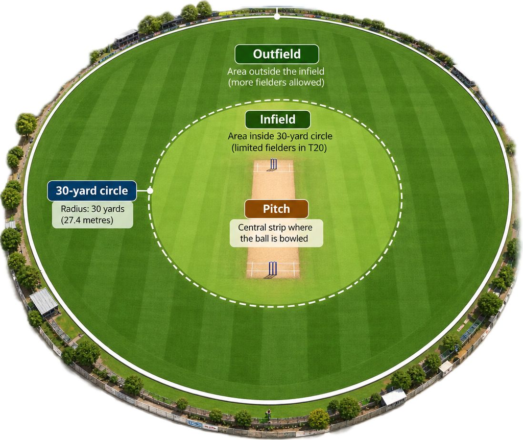

**Batting team:** scores runs  
**Bowling team:** takes wickets

#### T20 Cricket

- **20 overs per team**
- **6 legal balls per over**
- **10 wickets maximum**
- **First innings:** sets the target
- **Second innings:** chases the target
- **Toss:** choose to bat or field
- **Win:** finish with the higher score

### Research Questions

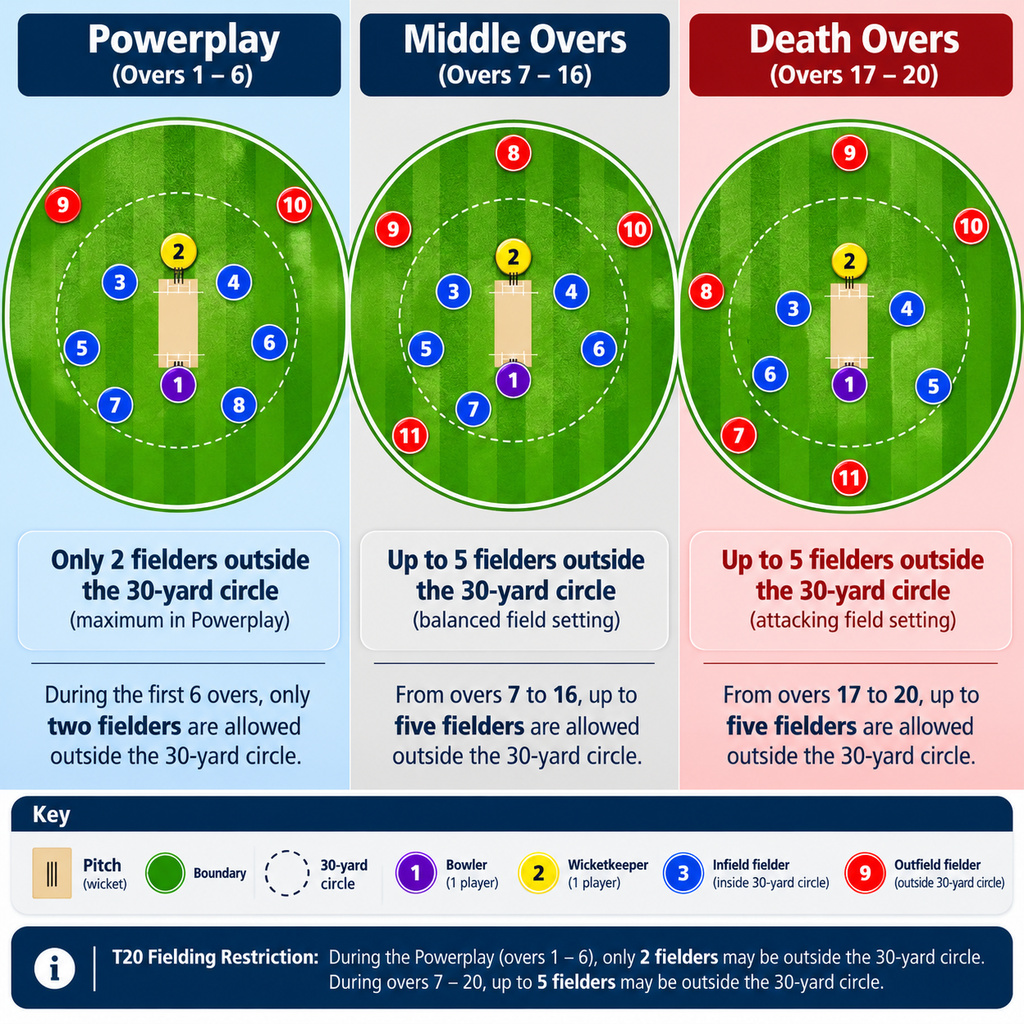

#### 1. Scoring & Wickets by Phase

**How do scoring rates and wicket probabilities vary across the three phases of a T20 innings?**

- **Powerplay:** 1–6
- **Middle:** 7–16
- **Death:** 17–20

#### 2. Batsmen Performance Under Pressure

**Which batters perform best under high-pressure chase situations compared with low-pressure situations?**

Pressure depends on:

- **Required run rate**
- **Wickets in hand**
- **Balls remaining**

##### Can we build a model that predicts the probability of a wicket falling on any given delivery, using match-state and player-identity features?

. . .

Feature engineering

- Match State Features
- Player Features
- Momentum Features
- Partnership Variables

#### The Model

Predicted vs actual wickets by phase of play

| Phase | Deliveries | Predicted wickets | Actual wickets | Predicted wicket rate | Actual wicket rate | Predicted minus actual |
| --- | --- | --- | --- | --- | --- | --- |
| Powerplay (overs 1-6) | 9,176 | 394 | 398 | 4.30% | 4.34% | −0.04% |
| Middle (overs 7-16) | 14,968 | 711 | 720 | 4.75% | 4.81% | −0.06% |
| Death (overs 17-20) | 4,967 | 423 | 481 | 8.51% | 9.68% | −1.17% |
| All deliveries | 29,111 | 1,528 | 1,599 | 5.25% | 5.49% | −0.24% |

Predicted wickets = sum of the model's predicted probabilities over the deliveries in the phase.

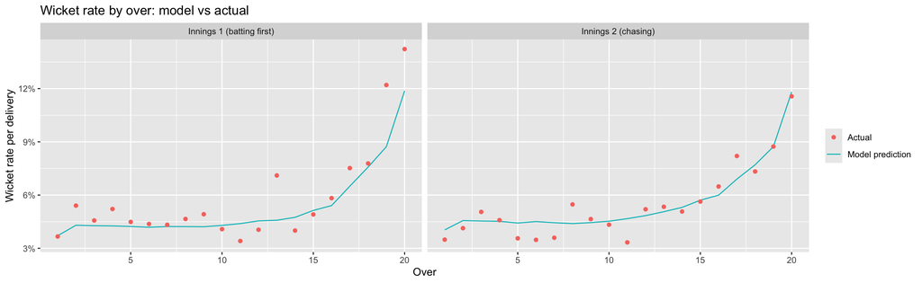

#### The Model

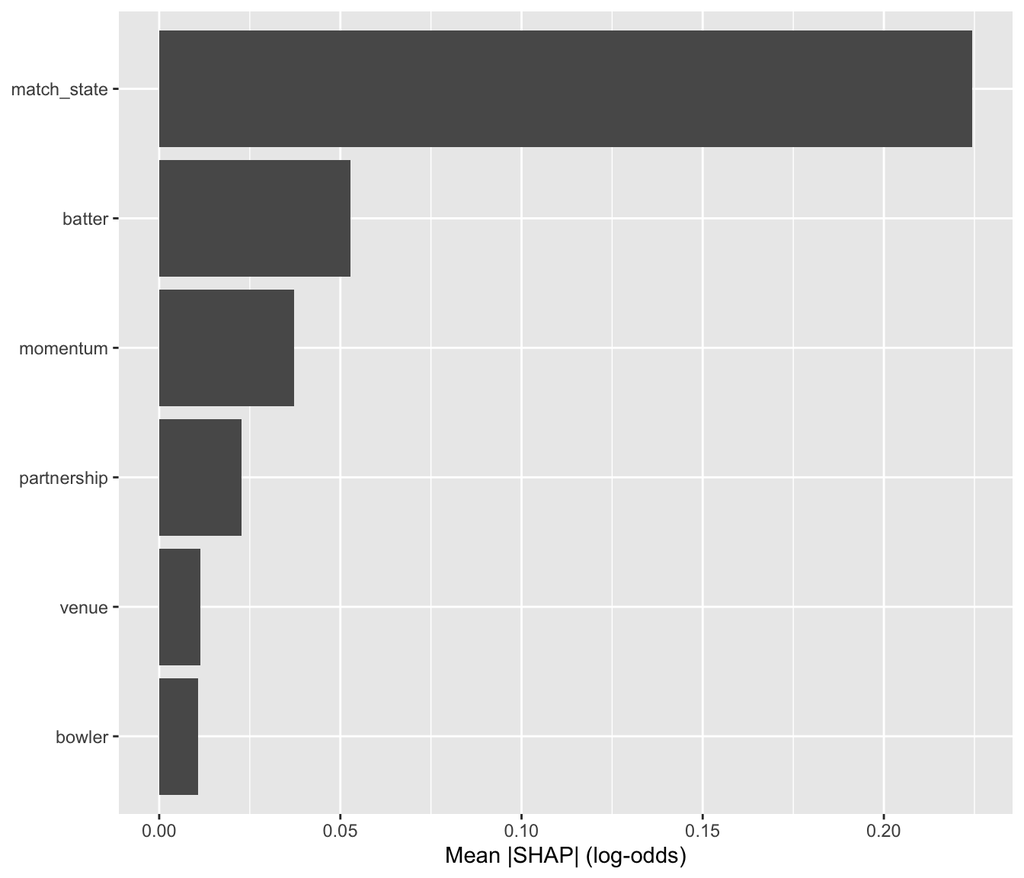

What drives the model’s predictions

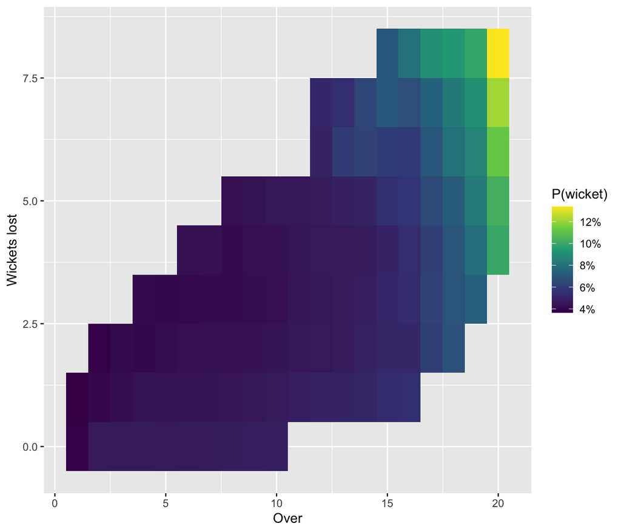

Wicket probability heatmap by over

##### Which bowlers are most effective at restricting runs and taking wickets in the death overs, after controlling for the match state they bowl in?

. . .

Why Raw Economy Fails

. . .

The Models

. . .

Baseline Calculation

#### Results

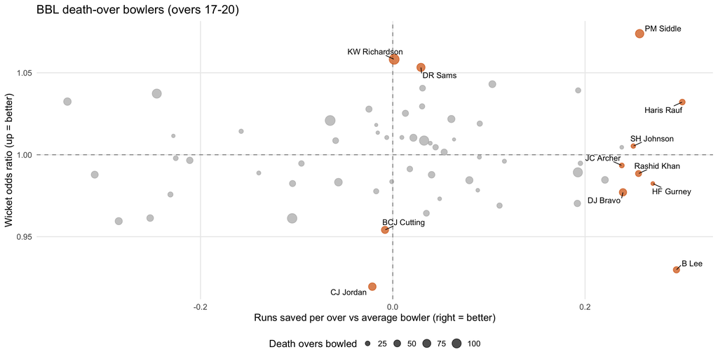

##### Does winning the toss and choosing to field (the more common decision in T20) actually translate into a meaningful advantage?

Feature Engineering:

- Cleaned venue name inconsistencies across seasons.
- Binary Indicators:
  - `toss_winner_is_home_team`: did the toss winner enjoyed home-ground support?
  - `winner_same_as_toss_winner`: did the toss winner ultimately won the match?
- Converted venue and match condition variables into factors.

Baseline Win Rates by Toss Decision

| toss_decision | total_matches | toss_winner_wins | win_rate_pct |
| --- | --- | --- | --- |
| bat | 248 | 125 | 50.40 |
| field | 399 | 218 | 54.64 |

Chi-Square Test of Independence

| statistic | p.value | parameter |
| --- | --- | --- |
| 0.94 | 0.33 | 1 |

- **Chi-Square Test Result:** winning the toss alone does not guarantee a competitive edge.

##### Does winning the toss and choosing to field (the more common decision in T20) actually translate into a meaningful advantage?

|  | Same winner as toss winner |  |  |
| --- | --- | --- | --- |
| Predictors | Odds Ratios | CI | p |
| stadiumBellerive Oval (Ninja Stadium) | 1.11 | 0.58 – 2.13 | 0.746 |
| stadiumKardinia Park (GMHBA Stadium) | 0.96 | 0.29 – 3.24 | 0.948 |
| stadiumManuka Oval | 0.74 | 0.31 – 1.77 | 0.503 |
| stadiumMarvel Stadium | 0.99 | 0.52 – 1.88 | 0.975 |
| stadiumMelbourne Cricket Ground (MCG) | 1.09 | 0.57 – 2.06 | 0.801 |
| stadiumMetricon Stadium (Carrara Stadium) | 0.86 | 0.30 – 2.42 | 0.767 |
| stadiumOptus Stadium | 0.61 | 0.29 – 1.25 | 0.179 |
| stadiumOther | 0.88 | 0.28 – 2.78 | 0.818 |
| stadiumStadium Australia | 0.54 | 0.15 – 1.75 | 0.309 |
| stadiumSydney Cricket Ground (SCG) | 1.08 | 0.56 – 2.09 | 0.826 |
| stadiumSydney Showground Stadium | 1.01 | 0.47 – 2.17 | 0.987 |
| stadiumThe Gabba | 0.86 | 0.45 – 1.66 | 0.660 |
| stadiumUniversity of Tasmania Stadium | 0.79 | 0.20 – 3.05 | 0.723 |
| stadiumWACA Ground | 1.30 | 0.58 – 2.96 | 0.525 |
| toss_decisionfield | 1.18 | 0.85 – 1.64 | 0.323 |
| toss_winner_is_home_teamTRUE | 1.26 | 0.91 – 1.74 | 0.164 |
| Observations | 647 |  |  |
| R<sup>2</sup> Tjur | 0.014 |  |  |

|  | Same winner as toss winner |  |  |
| --- | --- | --- | --- |
| Predictors | Odds Ratios | CI | p |
| toss decision [field] | 1.18 | 0.85 – 1.64 | 0.323 |
| toss winner is home teamTRUE | 1.26 | 0.91 – 1.74 | 0.164 |
| Observations | 647 |  |  |
| R<sup>2</sup> Tjur | 0.014 |  |  |

##### Do players naturally cluster into distinct batting or bowling archetypes based on their ball-by-ball performance profiles?

| Feature Type | Batter Feature | Bowler Feature | Tactical Significance |
| --- | --- | --- | --- |
| **Efficiency** | `strike_rate` | `economy_rate` | Overall scoring pace vs. run restriction |
| **Control** | `dot_pct` | `dot_pct` | Strike rotation capability vs. pressure generation |
| **Aggression** | `boundary_pct` | `boundary_conceded_pct` | Big-hit frequency vs. boundary suppression |
| **Phase: PP** | `pp_ball_pct` | `pp_ball_pct` | Delivery volume in Overs 1–6 (Field Restrictions) |
| **Phase: Death** | `death_ball_pct` | `death_ball_pct` | Delivery volume in Overs 17–20 (High-Risk Finish) |

Apply k-means clustering

##### Batters

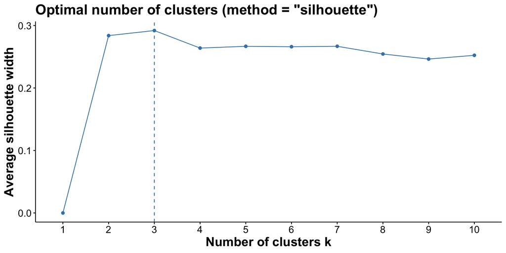

##### Batters

[interactive chart not shown]

- Cluster 1: Aggressive Powerplay boundary hitters
- Cluster 2: Low-impact lower-order tailenders
- Cluster 3: High-rotation middle-order anchors

##### Bowlers

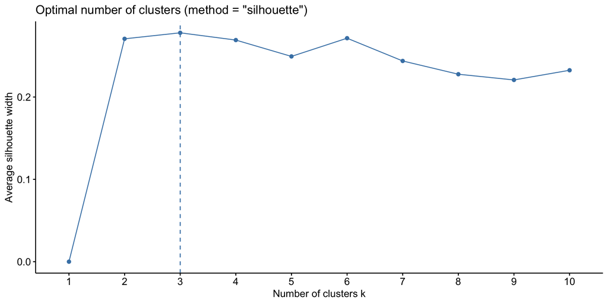

##### Bowlers

[interactive chart not shown]

- Cluster 1: High-dot new-ball pace attackers
- Cluster 2: Low-economy middle-over run suppressors
- Cluster 3: High-variance late-over death specialists

#### Stakeholders, Limitations and Future Scope

- BBL coaches, analysts and recruiters.
- Missing fitness, pitch and tracking data.
- Integrate more data sources and T20 leagues.